# task1_d604

```python
# D604: Task 1 Neural Networks
```

A1. Can a neural network model accurately classify RGB images of plant seedlings into their respective species to support automated weed detection and crop management in agricultural settings?

A2. One goal of the analysis is to build a neural network model that will classify the twelve seedling species with an accuracy of at least 85%. Since the dataset includes 4,750 images across twelve classes, the dataset’s size will support training for multi-class classification. Another goal of the analysis is to identify any visual features that set crop seedlings apart from weeds to provide insights for decision-making. This is achievable since the RBG images contain detailed visual data that can be analyzed after training. A third goal is to minimize the misclassification of crops as weeds and prevent the unnecessary removal of valuable plants by correctly identifying them. Precision and recall can be balanced by identifying these false positives, and the labeled data in labels.csv supports this approach.

A3. I will use a Convolutional Neural Network (CNN) for this analysis. CNNs are a good choice for multi-class image classification. They are equipped to process the 4750 RGB images and classify them into twelve categories.

A4. CNNs use convolutional layers to find spatial patterns such as leaf edges, vein structures, and color variations. CNNs can also use color information to distinguish species of plants, which will be helpful when differentiating a weed from a plant. They are widely used in agriculture already for weed detection and crop monitoring. CNN also uses pooling layers to reduce the image dimensionality. This makes the training process easier to process with a large dataset. Finally, CNN works well with a SoftMax output layer to handle the twelve-class classification process well. Other alternative methods may struggle with high-dimensional image data.

```python
import pandas as pd
import matplotlib.pyplot as plt
import numpy as np
from tensorflow.keras.preprocessing.image import ImageDataGenerator
from sklearn.model_selection import train_test_split
from tensorflow.keras.utils import to_categorical
from sklearn.preprocessing import LabelEncoder
from tensorflow.keras.models import Sequential
from tensorflow.keras.layers import Conv2D, MaxPooling2D, Flatten, Dense, Dropout
from tensorflow.keras.callbacks import EarlyStopping
from sklearn.metrics import confusion_matrix
import seaborn as sns
import matplotlib.pyplot as plt

# Load labels
labels = pd.read_csv("labels.csv")

# Print column names and first few rows to inspect
print("Column names:", labels.columns.tolist())
print("First 5 rows:\n", labels.head())

class_counts = labels.iloc[:, 0].value_counts()
```

```
Column names: ['Label']
First 5 rows:
                        Label
0  Small-flowered Cranesbill
1  Small-flowered Cranesbill
2  Small-flowered Cranesbill
3  Small-flowered Cranesbill
4  Small-flowered Cranesbill
```

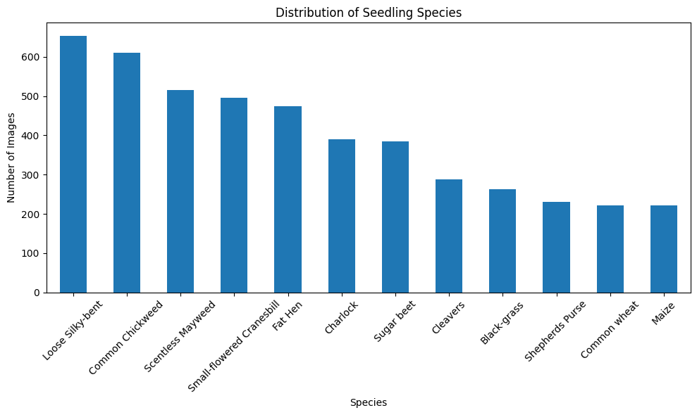

```python
# B1a: Visualization for class distribution
plt.figure(figsize=(10, 6))
class_counts.plot(kind='bar')
plt.title('Distribution of Seedling Species')
plt.xlabel('Species')
plt.ylabel('Number of Images')
plt.xticks(rotation=45)
plt.tight_layout()
plt.savefig('class_distribution.png')  # Save for screenshot
plt.show()
```

B1a. The bar chart in Figure 1 was created to show the distribution of the twelve seedling species in the dataset. The plot uses the counts of each unique value in the labels.csv sheet.

Figure 1: Distribution of Seedling Species

[figure not shown]

```python
# B1b: Sample images with associated labels
images = np.load("images.npy")  # Shape: (4750, 128, 128, 3)

# Get unique classes and one sample per class
unique_classes = labels.iloc[:, 0].unique()
plt.figure(figsize=(15, 5))

for i, species in enumerate(unique_classes):
    idx = labels[labels.iloc[:, 0] == species].index[0]  # First occurrence
    plt.subplot(2, 6, i + 1)  # 2 rows, 6 cols for 12 classes
    plt.imshow(images[idx])
    plt.title(species, fontsize=10)
    plt.axis('off')

plt.tight_layout()
plt.savefig('sample_images.png')  # Save for screenshot
plt.show()
```

[output not shown]

```python
# B2: Perform Data Augmentation
datagen = ImageDataGenerator(
    rotation_range=30,
    horizontal_flip=True,
    brightness_range=[0.8, 1.2],
    zoom_range=0.2,
    fill_mode='nearest'
)
```

```python
# B3: Normalize the Images
images_normalized = images.astype('float32') / 255.0
print(images_normalized.min(), images_normalized.max())  # Should print 0.0, 1.0

X_train, X_temp, y_train, y_temp = train_test_split(
    images_normalized, labels.iloc[:, 0], test_size=0.3, stratify=labels.iloc[:, 0], random_state=42
)
```

```
0.0 1.0
```

B3. In this section, the pixel values are scaled to [0, 1] to standardize input for the CNN. This aids in the optimization process and improves compatibility with common frameworks.

```python
# B4: Perform Training (70%), Validation (15%), and  Test (15%) Split
X_val, X_test, y_val, y_test = train_test_split(
    X_temp, y_temp, test_size=0.5, stratify=y_temp, random_state=42
)
print(X_train.shape, X_val.shape, X_test.shape)  # (3325, 128, 128, 3), (712, 128, 128, 3), (713, 128, 128, 3)
```

```
(3325, 128, 128, 3) (712, 128, 128, 3) (713, 128, 128, 3)
```

B4. By keeping 70% of the data in the training dataset and putting 15% in the validation and test sets, respectively, it can be ensured that sufficient data is used for training and evaluation. This preserves the overall class balance.

```python
# B5: Encode the target feature for all datasets
le = LabelEncoder()
y_train_encoded = le.fit_transform(y_train)  # y_train from split
y_val_encoded = le.transform(y_val)
y_test_encoded = le.transform(y_test)

y_train_onehot = to_categorical(y_train_encoded, num_classes=12)
y_val_onehot = to_categorical(y_val_encoded, num_classes=12)
y_test_onehot = to_categorical(y_test_encoded, num_classes=12)
print(y_train_onehot.shape)  # (3325, 12)
```

```
(3325, 12)
```

B5. The labels are encoded as integers (0-11) and then one-hot encoded into 12D vectors for multi-class classification, matching the CNNs SoftMax output.

```python
# B6: Provide a copy of all datasets
np.save('task1_X_train.npy', X_train)
np.save('task1_X_val.npy', X_val)
np.save('task1_X_test.npy', X_test)
np.save('task1_y_train_onehot.npy', y_train_onehot)
np.save('task1_y_val_onehot.npy', y_val_onehot)
np.save('task1_y_test_onehot.npy', y_test_onehot)
```

B6. A copy of all datasets have been uploaded.

```python
# Before E1: Load the saved datasets
X_train = np.load('task1_X_train.npy')
X_val = np.load('task1_X_val.npy')
X_test = np.load('task1_X_test.npy')
y_train_onehot = np.load('task1_y_train_onehot.npy')
y_val_onehot = np.load('task1_y_val_onehot.npy')
y_test_onehot = np.load('task1_y_test_onehot.npy')
```

```python
# E1: Output of Model Summary
model = Sequential([
    Conv2D(32, (3, 3), activation='relu', input_shape=(128, 128, 3)),
    MaxPooling2D((2, 2)),
    Conv2D(64, (3, 3), activation='relu'),
    MaxPooling2D((2, 2)),
    Conv2D(128, (3, 3), activation='relu'),
    MaxPooling2D((2, 2)),
    Flatten(),
    Dense(128, activation='relu'),
    Dropout(0.5),
    Dense(12, activation='softmax')
])
model.compile(optimizer='adam', loss='categorical_crossentropy', metrics=['accuracy'])
model.summary()
```

```
Model: "sequential_1"
```

```
┏━━━━━━━━━━━━━━━━━━━━━━━━━━━━━━━━━━━━━━┳━━━━━━━━━━━━━━━━━━━━━━━━━━━━━┳━━━━━━━━━━━━━━━━━┓
┃ Layer (type)                         ┃ Output Shape                ┃         Param # ┃
┡━━━━━━━━━━━━━━━━━━━━━━━━━━━━━━━━━━━━━━╇━━━━━━━━━━━━━━━━━━━━━━━━━━━━━╇━━━━━━━━━━━━━━━━━┩
│ conv2d_3 (Conv2D)                    │ (None, 126, 126, 32)        │             896 │
├──────────────────────────────────────┼─────────────────────────────┼─────────────────┤
│ max_pooling2d_3 (MaxPooling2D)       │ (None, 63, 63, 32)          │               0 │
├──────────────────────────────────────┼─────────────────────────────┼─────────────────┤
│ conv2d_4 (Conv2D)                    │ (None, 61, 61, 64)          │          18,496 │
├──────────────────────────────────────┼─────────────────────────────┼─────────────────┤
│ max_pooling2d_4 (MaxPooling2D)       │ (None, 30, 30, 64)          │               0 │
├──────────────────────────────────────┼─────────────────────────────┼─────────────────┤
│ conv2d_5 (Conv2D)                    │ (None, 28, 28, 128)         │          73,856 │
├──────────────────────────────────────┼─────────────────────────────┼─────────────────┤
│ max_pooling2d_5 (MaxPooling2D)       │ (None, 14, 14, 128)         │               0 │
├──────────────────────────────────────┼─────────────────────────────┼─────────────────┤
│ flatten_1 (Flatten)                  │ (None, 25088)               │               0 │
├──────────────────────────────────────┼─────────────────────────────┼─────────────────┤
│ dense_2 (Dense)                      │ (None, 128)                 │       3,211,392 │
├──────────────────────────────────────┼─────────────────────────────┼─────────────────┤
│ dropout_1 (Dropout)                  │ (None, 128)                 │               0 │
├──────────────────────────────────────┼─────────────────────────────┼─────────────────┤
│ dense_3 (Dense)                      │ (None, 12)                  │           1,548 │
└──────────────────────────────────────┴─────────────────────────────┴─────────────────┘
```

```
 Total params: 3,306,188 (12.61 MB)
```

```
 Trainable params: 3,306,188 (12.61 MB)
```

```
 Non-trainable params: 0 (0.00 B)
```

E2a. The CNN model consists of 10 layers, as shown in the model summary. These include three Conv2D, three MaxPooling2D, one Flatten layer, two Dense layers, and one Dropout layer. This architecture effectively combines convolutional layers for feature extraction, pooling layers for dimensionality reduction, and dense layers for classification, with dropout to enhance generalization.

E2b.

1. The CNN model uses five types of layers. These are Conv2D, MaxPooling2D, Flatten, Dense, and Dropout. These layers effectively classify the RGB images of plant seedlings into 12 species. Three Conv2D layers were selected because they are ideal for image data as they identify features such as edges, textures, and patterns. Three MaxPooling2D layers were included to reduce dimensions after each Conv2D layer, which decreases computational complexity and helps to prevent overfitting by focusing on dominant features. A Flatten layer was chosen to transform the 3D feature map into a 1D vector. Two Dense layers were used because they are lean complex relationships between features and perform classifications. Lastly, a Dropout layer was used to address any overfitting. This combination of layer types creates an excellent architecture for feature extraction, size reduction, and classification to meet the needs of the agricultural image classification task.

E2c.

1. 1. Conv2D: For feature extraction
- This Conv2D layer has 32 filters and finds basic features such as edges and textures from the 128x128x3 input images.
2. MaxPooling2D: For size reduction
- This layer reduces the dimensions from 126x126 to 63x63. This decreases the computational complexity, helps the model to focus on dominant features, and reduces overfitting.
3. Conv2D: More complex feature extraction
- This Conv2D layer has 64 filters. It extracts more complex features, such as patterns or shapes, and builds on the first Conv2D layer.
4. MaxPooling2D:
- This MaxPooling2D layer further reduces the dimensions to 30x30, enhances translation invariance, and focuses on higher-level features.
5. Conv2D:
- This Conv2D layer has 128 filters. It captures more abstract features, such as seedling characteristics, by combining the features from previous layers.
6. MaxPooling2D:
- This layer reduces the dimensions to 14x14, minimizes the computation load, and prevents overfitting.
7. Flatten: For transition to dense layers.
- Flatten prepares the data to be classified. It converts the final output and flattens it into a single vector. This makes it more usable for other layers.
8. Dense: For classification
- Dense layers combine the features to make a decision. Every node in this layer connects to every value in the previous layer. It learns how to weigh the features to predict the species. This Dense layer has 128 units.
9. Dropout: For regularization
- Dropout prevents memorization of the data. It randomly blocks some nodes during training so the model doesn’t memorize the data or make quick conclusions.
10. Dense:
- This final layer has 12 units and outputs the probabilities for each of the 12 seedling classes. This enables the model to classify the image into the correct species.

```python
# Early stopping for E3d and E4
early_stopping = EarlyStopping(monitor='val_loss', patience=5, restore_best_weights=True)
```

E2d.

1. The first layer, a Conv2D layer, has 896 parameters and allows the layer to learn basic features while keeping the parameter count low to prevent overfitting.
2. The second layer, a MaxPooling2D layer, has zero parameters since it performs a non-trainable max operation and reduces the dimensions from 126x126 to 63x63.
3. The third layer, another Conv2D layer, has 18,496 parameters. This allows the layer to learn more complex features with a doubled number of filters.
4. The fourth layer, another MaxPooling2D layer, has zero parameters and reduces the dimensions to 30x30.
5. The fifth layer, a third Conv2D layer, has 73,856 parameters. This provides a large enough amount to distinguish the 12 species by finding detailed patterns.
6. The sixth layer, a third MaxPooling 2D layer, has zero parameters and reduces the dimensions to 14x14.
7. The seventh layer, Flatten, has zero parameters and reshapes the 14x14x128 feature maps into a 1D vector.
8. The eighth layer, a Dense layer, has 128 units and 3,211,392 parameters. This layer has the most parameters since there is a significant input size. The 128 units balance complexity and any risk of overfitting.
9. The ninth layer, a Dropout layer, has zero parameters. It randomly turns off 50% of the units during training to prevent overfitting.
10. The tenth layer, Dense, has 12 units and 1,548 parameters. It produces the final probabilities for the 12 seedling classes. The final parameter count is 3,306,188 and reflects a model that balances a capacity for feature learning with computational efficiency.

E2e. The CNN model uses ReLU and softmax activation functions, chosen for their effectiveness in enabling non-linear learning and multi-class classification for the seedling dataset. ReLU (Rectified Linear Unit) is used in the hidden layers, specifically the three Conv2D layers and the first Dense layer because it introduces non-linearity by outputting the input if positive or 0 otherwise and allows the model to learn complex patterns like edges, textures, and seedling-specific features. ReLU reduces the risk of overfitting by encouraging the model to focus on the most relevant features. The softmax activation function is used in the output Dense layer to convert raw scores into probabilities for the 12 seedling classes, ensuring the probabilities sum to 1. The remaining layers do not use activation functions, as they perform pooling, reshaping, and regularization rather than transformations requiring non-linearity. The combination of ReLU and softmax ensures the model can effectively learn hierarchical features and classify seedlings accurately.

E3a. The choice for loss function was categorical crossentropy. It measures the error between predicted probabilities and accurate one-hot labels. This encourages the model to maximize confidence in the correct class and align with the Softmax output.

E3b. Adaptive Movement Estimation (Adam) was chosen as the optimizer. It updates the 3,306,188 parameters efficiently by adapting the learning rate, providing a fast and stable convergence. This works well with the CNN’s complexity and the large image dataset.

E3c. The default Adam learning rate of 0.001 is chosen since it provides a balanced step size for weight updates and is suitable for the provided dataset and several parameters. Adam’s ability to adapt fine-tunes the learning rate, making 0.001 a practical starting point for this CNN.

E3d. Early stopping with a patience of 5 and monitoring validation loss is chosen to stop training when loss doesn’t improve. This prevents overfitting on the 3,325 training images. Restoring the best weights maximizes the task's performance, making it more efficient and effective for the dataset size.

```
104/104 ━━━━━━━━━━━━━━━━━━━━ 10s 86ms/step - accuracy: 0.1217 - loss: 2.4708 - val_accuracy: 0.1278 - val_loss: 2.4310
104/104 ━━━━━━━━━━━━━━━━━━━━ 8s 80ms/step - accuracy: 0.1593 - loss: 2.3878 - val_accuracy: 0.3862 - val_loss: 1.8702
104/104 ━━━━━━━━━━━━━━━━━━━━ 8s 79ms/step - accuracy: 0.3510 - loss: 1.8784 - val_accuracy: 0.5169 - val_loss: 1.5111
104/104 ━━━━━━━━━━━━━━━━━━━━ 8s 80ms/step - accuracy: 0.4371 - loss: 1.6026 - val_accuracy: 0.5857 - val_loss: 1.2934
104/104 ━━━━━━━━━━━━━━━━━━━━ 8s 79ms/step - accuracy: 0.5059 - loss: 1.3500 - val_accuracy: 0.6615 - val_loss: 1.0680
104/104 ━━━━━━━━━━━━━━━━━━━━ 8s 80ms/step - accuracy: 0.5810 - loss: 1.1941 - val_accuracy: 0.6601 - val_loss: 1.0269
104/104 ━━━━━━━━━━━━━━━━━━━━ 8s 79ms/step - accuracy: 0.6208 - loss: 1.0657 - val_accuracy: 0.7051 - val_loss: 0.8852
104/104 ━━━━━━━━━━━━━━━━━━━━ 9s 82ms/step - accuracy: 0.6695 - loss: 0.9575 - val_accuracy: 0.7416 - val_loss: 0.8454
104/104 ━━━━━━━━━━━━━━━━━━━━ 8s 79ms/step - accuracy: 0.6748 - loss: 0.9211 - val_accuracy: 0.7725 - val_loss: 0.7507
104/104 ━━━━━━━━━━━━━━━━━━━━ 8s 80ms/step - accuracy: 0.6906 - loss: 0.8360 - val_accuracy: 0.7893 - val_loss: 0.7394
104/104 ━━━━━━━━━━━━━━━━━━━━ 8s 80ms/step - accuracy: 0.7083 - loss: 0.7829 - val_accuracy: 0.7767 - val_loss: 0.7288
104/104 ━━━━━━━━━━━━━━━━━━━━ 8s 79ms/step - accuracy: 0.7528 - loss: 0.6802 - val_accuracy: 0.7626 - val_loss: 0.7330
104/104 ━━━━━━━━━━━━━━━━━━━━ 8s 80ms/step - accuracy: 0.7670 - loss: 0.6462 - val_accuracy: 0.7683 - val_loss: 0.7267
104/104 ━━━━━━━━━━━━━━━━━━━━ 8s 79ms/step - accuracy: 0.7789 - loss: 0.6414 - val_accuracy: 0.7879 - val_loss: 0.6855
104/104 ━━━━━━━━━━━━━━━━━━━━ 8s 80ms/step - accuracy: 0.7769 - loss: 0.5700 - val_accuracy: 0.7949 - val_loss: 0.6918
104/104 ━━━━━━━━━━━━━━━━━━━━ 8s 81ms/step - accuracy: 0.8053 - loss: 0.5573 - val_accuracy: 0.7949 - val_loss: 0.6705
104/104 ━━━━━━━━━━━━━━━━━━━━ 8s 80ms/step - accuracy: 0.8092 - loss: 0.5310 - val_accuracy: 0.7893 - val_loss: 0.6937
104/104 ━━━━━━━━━━━━━━━━━━━━ 8s 80ms/step - accuracy: 0.8058 - loss: 0.5175 - val_accuracy: 0.7851 - val_loss: 0.6826
104/104 ━━━━━━━━━━━━━━━━━━━━ 8s 80ms/step - accuracy: 0.8298 - loss: 0.4643 - val_accuracy: 0.7949 - val_loss: 0.6677
104/104 ━━━━━━━━━━━━━━━━━━━━ 8s 80ms/step - accuracy: 0.8273 - loss: 0.4762 - val_accuracy: 0.7963 - val_loss: 0.7134
104/104 ━━━━━━━━━━━━━━━━━━━━ 8s 81ms/step - accuracy: 0.8281 - loss: 0.4688 - val_accuracy: 0.7963 - val_loss: 0.7162
104/104 ━━━━━━━━━━━━━━━━━━━━ 8s 82ms/step - accuracy: 0.8631 - loss: 0.3903 - val_accuracy: 0.7907 - val_loss: 0.7752
104/104 ━━━━━━━━━━━━━━━━━━━━ 8s 80ms/step - accuracy: 0.8536 - loss: 0.3727 - val_accuracy: 0.8006 - val_loss: 0.7940
104/104 ━━━━━━━━━━━━━━━━━━━━ 8s 80ms/step - accuracy: 0.8385 - loss: 0.4235 - val_accuracy: 0.7893 - val_loss: 0.8037
23/23 ━━━━━━━━━━━━━━━━━━━━ 1s 22ms/step
```

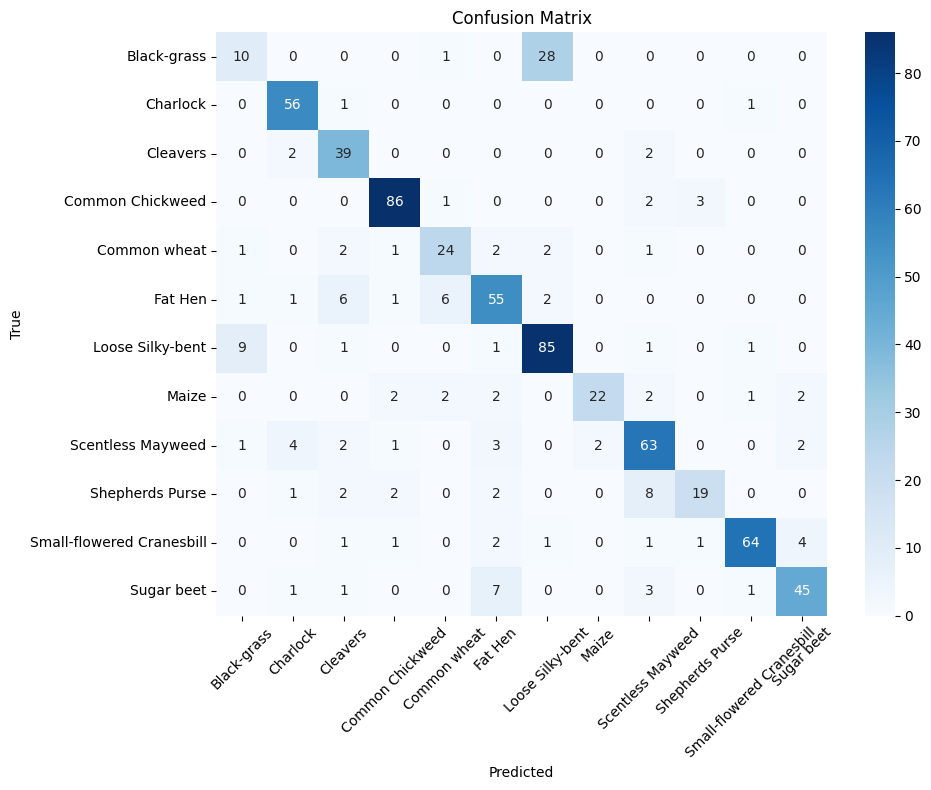

```python
# E4: Confusion Matrix
# Train the model
history = model.fit(
    X_train, y_train_onehot,
    validation_data=(X_val, y_val_onehot),
    epochs=50, batch_size=32, callbacks=[early_stopping]
)

# Predict on test set
y_pred = model.predict(X_test)
y_pred_classes = np.argmax(y_pred, axis=1)  # Convert probabilities to class indices
y_test_classes = np.argmax(y_test_onehot, axis=1)  # Convert one-hot to class indices

# Generate confusion matrix
cm = confusion_matrix(y_test_classes, y_pred_classes)

# Plot confusion matrix
plt.figure(figsize=(10, 8))
sns.heatmap(cm, annot=True, fmt='d', cmap='Blues', xticklabels=le.classes_, yticklabels=le.classes_)
plt.title('Confusion Matrix')
plt.xlabel('Predicted')
plt.ylabel('True')
plt.xticks(rotation=45)
plt.tight_layout()
plt.savefig('task1_confusion_matrix.png')
plt.show()
```

```python
# F1a: Final training epoch
print("Final training epoch:", len(history.history['loss']))
print("Training loss:", history.history['loss'][-1])
print("Validation loss:", history.history['val_loss'][-1])
print("Training accuracy:", history.history['accuracy'][-1])
print("Validation accuracy:", history.history['val_accuracy'][-1])
```

```
Final training epoch: 24
Training loss: 0.40187475085258484
Validation loss: 0.8036959171295166
Training accuracy: 0.8427067399024963
Validation accuracy: 0.7893258333206177
```

```python
# F1b: Compare training vs. validation accuracy
final_train_acc = history.history['accuracy'][-1]
final_val_acc = history.history['val_accuracy'][-1]
print(f"Final Training Accuracy: {final_train_acc:.4f}")
print(f"Final Validation Accuracy: {final_val_acc:.4f}")
```

```
Final Training Accuracy: 0.8427
Final Validation Accuracy: 0.7893
```

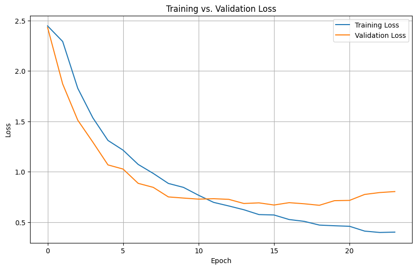

```python
# F1c: Training vs. validation loss plot
plt.figure(figsize=(10, 6))
plt.plot(history.history['loss'], label='Training Loss')
plt.plot(history.history['val_loss'], label='Validation Loss')
plt.title('Training vs. Validation Loss')
plt.xlabel('Epoch')
plt.ylabel('Loss')
plt.legend()
plt.grid(True)
plt.savefig('task1_train_val_loss.png')
plt.show()
```

G2. The botanists can take the following steps to improve the model’s predictive accuracy. First, more training data should be collected for underperforming classes like Common Wheat and Shepherds Purse to increase the dataset beyond 4750 images and improve feature learning. Second, data augmentation can be enhanced by adding techniques to better capture real-world variations in field images. Third, consider adding more Conv2D layers to extract complex features from the 128x128x3 images. Fourth, address the slight overfitting by increasing Dropout beyond 0.5. Finally, misclassifications between similar species can be tackled by using focal loss to focus on challenging classes or gathering more diverse samples for those species. These steps can enhance the model’s accuracy and reliability for agricultural classification tasks.